# Multiverse Syntax

## Introduction

In this document, we outline some initial avenues for creating the syntax for a multiverse analysis. The goal is to identify a high-level data structure that can be used consistently throughout the analysis and can be manipulated in ways similar to a data.frame or tibble.

## The data

The first step is to read the raw data from the file and store it as a tibble. We will be following the *tidy data* format here. The data is stored in two text files, and we can use `readr` to read the files into R. In this example, we will use the data collected by *Durante et al.*, which investigated the effect of fertility on religiosity and political attitudes. We will focus on their second study (which we store in `data.raw.study2`).

```r
data.raw.study2 <- read_delim("../data/durante_etal_2013_study2.txt", delim = "\t",
    col_types = cols(
        DateTesting = col_date(format = "%m/%d/%y"),
        StartDateofLastPeriod =col_date(format = "%m/%d/%y"),
        StartDateofPeriodBeforeLast = col_date(format = "%m/%d/%y"),
        StartDateNext = col_date(format = "%m/%d/%y")
  )) %>%
  mutate(
    Abortion = abs(7 - Abortion) + 1,
    StemCell = abs(7 - StemCell) + 1,
    Marijuana = abs(7 - Marijuana) + 1,
    RichTax = abs(7 - RichTax) + 1,
    StLiving = abs(7 - StLiving) + 1,
    Profit = abs(7 - Profit) + 1,
    FiscConsComp = FreeMarket + PrivSocialSec + RichTax + StLiving + Profit,
    SocConsComp = Marriage + RestrictAbortion + Abortion + StemCell + Marijuana
  ) %>%
  mutate(ComputedCycleLength = StartDateofLastPeriod - StartDateofPeriodBeforeLast )
```

The data look like this:

```r
data.raw.study2 %>%
  head(10)
```

```
## # A tibble: 10 x 27
##    WorkerID  Rel1  Rel2  Rel3 Abortion Marriage StemCell RestrictAbortion
##       <dbl> <dbl> <dbl> <dbl>    <dbl>    <dbl>    <dbl>            <dbl>
##  1        1     8     8     7        6        7        1                7
##  2        2     8     7     7        1        2        3                1
##  3        3     6     6     2        5        1        2                4
##  4        4     7     8     6        1        5        2                2
##  5        5     7     7     9        1        1        4                1
##  6        6     9     9     9        7        7        2                7
##  7        7     5     8     5        3        4        3                5
##  8        8     1     1     1        1        1        2                1
##  9        9     7     7     7        5        1        2                1
## 10       10     6     6     6        3        5        3                1
## # … with 19 more variables: Marijuana <dbl>, FreeMarket <dbl>,
## #   RichTax <dbl>, StLiving <dbl>, Profit <dbl>, PrivSocialSec <dbl>,
## #   Sure1 <dbl>, Sure2 <dbl>, Relationship <dbl>,
## #   ReportedCycleLength <dbl>, Vote <dbl>, Donate <dbl>,
## #   DateTesting <date>, StartDateofLastPeriod <date>,
## #   StartDateofPeriodBeforeLast <date>, StartDateNext <date>,
## #   FiscConsComp <dbl>, SocConsComp <dbl>, ComputedCycleLength <drtn>
```

The original paper looked at the relationship between fertility, relationship status, and religiousity. But there are many reasonable ways to have defined each of these three variables from this dataset, so it is a good candidate for multiverse analysis.

## A single data set analysis: one possible analysis among many

The data collected needs to be processed before it can be modeled. Preparing the data set for analysis can involve several steps and decisions regarding how to encode the different raw values. The following is one example of data processing that can be performed for this study.

```r
one_universe = data.raw.study2 %>%
  mutate( ComputedCycleLength = StartDateofLastPeriod - StartDateofPeriodBeforeLast ) %>%
  mutate( NextMenstrualOnset = StartDateofLastPeriod + ComputedCycleLength ) %>%
  mutate(
    CycleDay = 28 - (NextMenstrualOnset - DateTesting),
    CycleDay = ifelse(CycleDay > 1 & CycleDay < 28, CycleDay, ifelse(CycleDay < 1, 1, 28))
  ) %>%
  mutate(
    Relationship = factor(ifelse(Relationship==1 | Relationship==2, "Single", "Relationship"))
  ) %>%
  filter( ComputedCycleLength > 25 & ComputedCycleLength < 35) %>%
  filter( Sure1 > 6 | Sure2 > 6 ) %>%
  mutate( Fertility = factor( ifelse(CycleDay >= 7 & CycleDay <= 14, "high", ifelse(CycleDay >= 17 & CycleDay <= 25, "low", "medium")) ) )
```

The transformed data for this one universe looks like this:

```r
one_universe %>%
  select( NextMenstrualOnset, Relationship, Sure1, Sure2, Fertility, everything() ) %>%
  head(10)
```

```
## # A tibble: 10 x 30
##    NextMenstrualOn… Relationship Sure1 Sure2 Fertility WorkerID  Rel1  Rel2
##    <date>           <fct>        <dbl> <dbl> <fct>        <dbl> <dbl> <dbl>
##  1 2012-06-17       Relationship     9     9 medium           1     8     8
##  2 2012-05-28       Relationship     9     7 low              2     8     7
##  3 2012-05-31       Relationship     8     7 low              3     6     6
##  4 2012-05-23       Single           8     8 medium           6     9     9
##  5 2012-05-31       Relationship     9     9 low              7     5     8
##  6 2012-06-15       Single           8     8 medium          11     2     5
##  7 2012-06-08       Relationship     9     8 high            12     7     7
##  8 2012-06-14       Relationship     9     8 medium          13     9     9
##  9 2012-06-10       Relationship     9     9 high            17     6     4
## 10 2012-06-18       Single           9     9 medium          18     9     9
## # … with 22 more variables: Rel3 <dbl>, Abortion <dbl>, Marriage <dbl>,
## #   StemCell <dbl>, RestrictAbortion <dbl>, Marijuana <dbl>,
## #   FreeMarket <dbl>, RichTax <dbl>, StLiving <dbl>, Profit <dbl>,
## #   PrivSocialSec <dbl>, ReportedCycleLength <dbl>, Vote <dbl>,
## #   Donate <dbl>, DateTesting <date>, StartDateofLastPeriod <date>,
## #   StartDateofPeriodBeforeLast <date>, StartDateNext <date>,
## #   FiscConsComp <dbl>, SocConsComp <dbl>, ComputedCycleLength <drtn>,
## #   CycleDay <dbl>
```

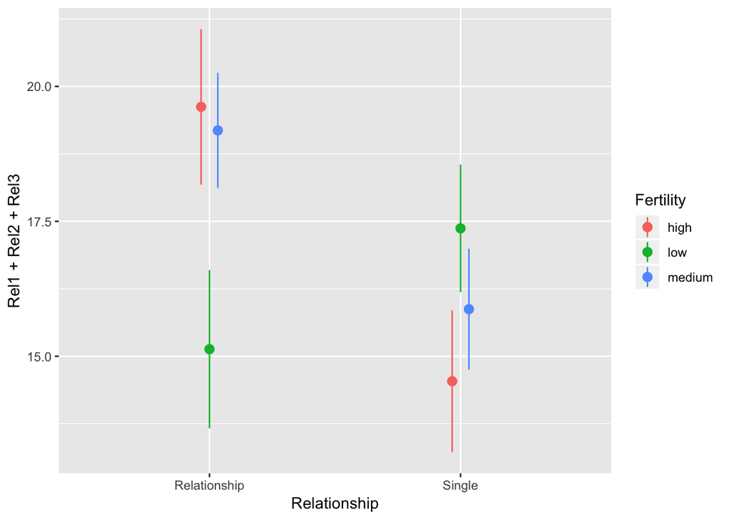

```r
one_universe %>%
  ggplot(aes(x = Relationship, y = Rel1 + Rel2 + Rel3, color = Fertility)) +
  stat_summary(position = position_dodge(width = .1), fun.data = "mean_se")
```

However, there also exists other valid processing options: instead of calculating `NextMenstrualOnset = StartDateofLastPeriod + ComputedCycleLength`, it can also be calculated as `StartDateofLastPeriod + ReportedCycleLength`. Such alternate processing options can exist for several decisions that a researcher makes in the data processing, analysis and presentation stages. This can thus result in a *multiverse of analysis*, with the one described above representing a single *universe*.

Below, we describe how our package allows you to conduct a multiverse analysis with ease.

## Defining the multiverse

`multidy` provides flexible functions which can be used to perform a multiverse analysis.

The first step is to define a *new multiverse*. We will use the multiverse object to create a set of universes, each representing a different way of analysing our data.

```r
M <- multiverse()
```

The next step is to define our possible analyses inside the multiverse. The `multidy` package includes functions that aim to make it easy to write multiverse analyses in as close a way to a single universe analysis as possible (as seen in the single analysis shown above).

Consider these first few lines from the transformation code in the single analysis above:

```r
df <- data.raw.study2  %>%
  mutate(ComputedCycleLength = StartDateofLastPeriod - StartDateofPeriodBeforeLast) %>%
  mutate(NextMenstrualOnset = StartDateofLastPeriod + ComputedCycleLength)
```

But `NextMenstrualOnset` could be calculated in at least two other reasonable ways:

- `NextMenstrualOnset = StartDateofLastPeriod + ReportedCycleLength`
- `NextMenstrualOnset = StartDateNext`

To create a multiverse that includes these three possible processing options, we can use the `branch()` function. The `branch()` function defines a *parameter* (here `menstrual_calculation`) and the different *options* that the parameter can take (here, `"mc_option1"`, `"mc_option2"`, `"mc_option3"`). Each option corresponds to a different chunk of code that would be executed in a different universe.

```r
inside(M, {
  df <- data.raw.study2  %>%
    mutate( ComputedCycleLength = StartDateofLastPeriod - StartDateofPeriodBeforeLast ) %>%
    mutate(NextMenstrualOnset = branch(menstrual_calculation,
      "mc_option1" ~ StartDateofLastPeriod + ComputedCycleLength,
      "mc_option2" ~ StartDateofLastPeriod + ReportedCycleLength,
      "mc_option3" ~ StartDateNext)
    )
})
```

Alternative to the `inside` function, we can use the more concise `<-` operator to define the multiverse. However, any expression on the right-hand-side of the `<-` operator needs to be preceded by the `~` (tilde) which converts the expression to a formula. Thus, the syntax looks like: `<multiverse_object>$<variable_name> <- ~ <expression>`

```r
M$df <- ~ data.raw.study2  %>%
  mutate( ComputedCycleLength = StartDateofLastPeriod - StartDateofPeriodBeforeLast ) %>%
    mutate(NextMenstrualOnset = branch(mentrual_calculation,
      "mc_option1" ~ StartDateofLastPeriod + ComputedCycleLength,
      "mc_option2" ~ StartDateofLastPeriod + ReportedCycleLength,
      "mc_option3" ~ StartDateNext)
    )
```

## Parsing the multiverse

The next step is to parse the multiverse to identify the `parameters` and the corresponding `options` that have been defined for each parameter. For this, we use the `parse_multiverse()` function.

The `multiverse` object we have defined consists of the following attributes: 1. `parameters`, which is a list of parameters

```r
M$parameters
```

```
## $menstrual_calculation
## $menstrual_calculation[[1]]
## [1] "mc_option1"
##
## $menstrual_calculation[[2]]
## [1] "mc_option2"
##
## $menstrual_calculation[[3]]
## [1] "mc_option3"
```

2. `conditions`, which is a list of conditions (we’ll define this later) *HAS NOT BEEN IMPLEMENTED YET*
3. `multiverse_table`, which is a tibble consisting of all possible combination of values for the multiverse

```r
M$multiverse_table
```

```
## # A tibble: 3 x 2
##   menstrual_calculation parameter_assignment
##   <chr>                 <list>
## 1 mc_option1            <list [1]>
## 2 mc_option2            <list [1]>
## 3 mc_option3            <list [1]>
```

4. `current_parameter_assignment`, which is a list of one set of options for each parameter defined in the multiverse. It initialises to the first option for each parameter. This should be the default analysis.

```r
M$current_parameter_assignment
```

```
## $menstrual_calculation
## [1] "mc_option1"
```

5. `code`, which is the code that the user passes to the multiverse to conduct a multiverse analysis. However, we do not execute this code and it is stored unevaluated. The user can interactively edit and rewrte this code, and can execute it for the current analysis or the entire multiverse using dedicated functions.

```r
M$code
```

```
## {
##     df <- data.raw.study2 %>% mutate(ComputedCycleLength = StartDateofLastPeriod -
##         StartDateofPeriodBeforeLast) %>% mutate(NextMenstrualOnset = branch(menstrual_calculation,
##         "mc_option1" ~ StartDateofLastPeriod + ComputedCycleLength,
##         "mc_option2" ~ StartDateofLastPeriod + ReportedCycleLength,
##         "mc_option3" ~ StartDateNext))
## }
```

## Running a single analysis from the multiverse

At this point, we have defined three possible processing options (three universes) in our multiverse, but no code has been executed. We need to be able to analyse each universe in turn. We can generate the code for a particular universe using the `get_code()`, and execute this code using `rlang::eval_tidy()`.

```r
get_code(M, list(menstrual_calculation = "mc_option2"))%>%
  rlang::eval_tidy() %>%
  select( NextMenstrualOnset, everything() )
```

```
## # A tibble: 502 x 28
##    NextMenstrualOn… WorkerID  Rel1  Rel2  Rel3 Abortion Marriage StemCell
##    <date>              <dbl> <dbl> <dbl> <dbl>    <dbl>    <dbl>    <dbl>
##  1 2012-06-15              1     8     8     7        6        7        1
##  2 2012-05-27              2     8     7     7        1        2        3
##  3 2012-05-31              3     6     6     2        5        1        2
##  4 2012-06-03              4     7     8     6        1        5        2
##  5 2012-05-27              5     7     7     9        1        1        4
##  6 2012-05-21              6     9     9     9        7        7        2
##  7 2012-05-31              7     5     8     5        3        4        3
##  8 NA                      8     1     1     1        1        1        2
##  9 NA                      9     7     7     7        5        1        2
## 10 2012-06-04             10     6     6     6        3        5        3
## # … with 492 more rows, and 20 more variables: RestrictAbortion <dbl>,
## #   Marijuana <dbl>, FreeMarket <dbl>, RichTax <dbl>, StLiving <dbl>,
## #   Profit <dbl>, PrivSocialSec <dbl>, Sure1 <dbl>, Sure2 <dbl>,
## #   Relationship <dbl>, ReportedCycleLength <dbl>, Vote <dbl>,
## #   Donate <dbl>, DateTesting <date>, StartDateofLastPeriod <date>,
## #   StartDateofPeriodBeforeLast <date>, StartDateNext <date>,
## #   FiscConsComp <dbl>, SocConsComp <dbl>, ComputedCycleLength <drtn>
```

These attributes are populated only after the `parse_multiverse()` function has been called on the multiverse object.

## A complete multiverse analysis

Besides calculating the onset of the next menstruation cycle, there are other variables which have multiple valid and reasonable processing options. These include defining `Relationship` and `Fertility`, and exclusion criteria based on the values for cycle length and certainty of responses. The next code chunk illustrates how this can be added to the multiverse object defined above.

```r
inside(M, {
  df %>%
    mutate(Relationship = branch( relationship_status,
      "rs_option1" ~ factor(ifelse(Relationship==1 | Relationship==2, 'Single', 'Relationship')),
      "rs_option2" ~ factor(ifelse(Relationship==1, 'Single', 'Relationship')),
      "rs_option3" ~ factor(ifelse(Relationship==1, 'Single', ifelse(Relationship==3 | Relationship==4, 'Relationship', NA))) )
    ) %>%
    mutate(
      CycleDay = 28 - (NextMenstrualOnset - DateTesting),
      CycleDay = ifelse(CycleDay > 1 & CycleDay < 28, CycleDay, ifelse(CycleDay < 1, 1, 28))
    ) %>%
    filter( branch(cycle_length,
      "cl_option1" ~ TRUE,
      "cl_option2" ~ ComputedCycleLength > 25 & ComputedCycleLength < 35,
      "cl_option3" ~ ReportedCycleLength > 25 & ReportedCycleLength < 35
    )) %>%
    filter( branch(certainty,
        "cer_option1" ~ TRUE,
        "cer_option2" ~ Sure1 > 6 | Sure2 > 6
    )) %>%
    mutate( Fertility = branch( fertile,
        "fer_option1" ~ factor( ifelse(CycleDay >= 7 & CycleDay <= 14, "high", ifelse(CycleDay >= 17 & CycleDay <= 25, "low", "medium")) ),
        "fer_option2" ~ factor( ifelse(CycleDay >= 6 & CycleDay <= 14, "high", ifelse(CycleDay >= 17 & CycleDay <= 27, "low", "medium")) ),
        "fer_option3" ~ factor( ifelse(CycleDay >= 9 & CycleDay <= 17, "high", ifelse(CycleDay >= 18 & CycleDay <= 25, "low", "medium")) ),
        "fer_option4" ~ factor( ifelse(CycleDay >= 8 & CycleDay <= 17, "high", "low") )
    ))
})
```

Since the multiverse object has already been created and the one parameter has already been defined, the inside function will add to the previous code.

```r
M$code
```

```
## {
##     df <- data.raw.study2 %>% mutate(ComputedCycleLength = StartDateofLastPeriod -
##         StartDateofPeriodBeforeLast) %>% mutate(NextMenstrualOnset = branch(menstrual_calculation,
##         "mc_option1" ~ StartDateofLastPeriod + ComputedCycleLength,
##         "mc_option2" ~ StartDateofLastPeriod + ReportedCycleLength,
##         "mc_option3" ~ StartDateNext))
##     df %>% mutate(Relationship = branch(relationship_status,
##         "rs_option1" ~ factor(ifelse(Relationship == 1 | Relationship ==
##             2, "Single", "Relationship")), "rs_option2" ~ factor(ifelse(Relationship ==
##             1, "Single", "Relationship")), "rs_option3" ~ factor(ifelse(Relationship ==
##             1, "Single", ifelse(Relationship == 3 | Relationship ==
##             4, "Relationship", NA))))) %>% mutate(CycleDay = 28 -
##         (NextMenstrualOnset - DateTesting), CycleDay = ifelse(CycleDay >
##         1 & CycleDay < 28, CycleDay, ifelse(CycleDay < 1, 1,
##         28))) %>% filter(branch(cycle_length, "cl_option1" ~
##         TRUE, "cl_option2" ~ ComputedCycleLength > 25 & ComputedCycleLength <
##         35, "cl_option3" ~ ReportedCycleLength > 25 & ReportedCycleLength <
##         35)) %>% filter(branch(certainty, "cer_option1" ~ TRUE,
##         "cer_option2" ~ Sure1 > 6 | Sure2 > 6)) %>% mutate(Fertility = branch(fertile,
##         "fer_option1" ~ factor(ifelse(CycleDay >= 7 & CycleDay <=
##             14, "high", ifelse(CycleDay >= 17 & CycleDay <= 25,
##             "low", "medium"))), "fer_option2" ~ factor(ifelse(CycleDay >=
##             6 & CycleDay <= 14, "high", ifelse(CycleDay >= 17 &
##             CycleDay <= 27, "low", "medium"))), "fer_option3" ~
##             factor(ifelse(CycleDay >= 9 & CycleDay <= 17, "high",
##                 ifelse(CycleDay >= 18 & CycleDay <= 25, "low",
##                   "medium"))), "fer_option4" ~ factor(ifelse(CycleDay >=
##             8 & CycleDay <= 17, "high", "low"))))
## }
```

Next, we use the `parse_multiverse()` function

We can then inspect the `multiverse_table` to see if all the possible combinations of the parameter options have been identified.

```r
M$multiverse_table
```

```
## # A tibble: 216 x 6
##    menstrual_calcu… relationship_st… cycle_length certainty fertile
##    <chr>            <chr>            <chr>        <chr>     <chr>
##  1 mc_option1       rs_option1       cl_option1   cer_opti… fer_op…
##  2 mc_option2       rs_option1       cl_option1   cer_opti… fer_op…
##  3 mc_option3       rs_option1       cl_option1   cer_opti… fer_op…
##  4 mc_option1       rs_option2       cl_option1   cer_opti… fer_op…
##  5 mc_option2       rs_option2       cl_option1   cer_opti… fer_op…
##  6 mc_option3       rs_option2       cl_option1   cer_opti… fer_op…
##  7 mc_option1       rs_option3       cl_option1   cer_opti… fer_op…
##  8 mc_option2       rs_option3       cl_option1   cer_opti… fer_op…
##  9 mc_option3       rs_option3       cl_option1   cer_opti… fer_op…
## 10 mc_option1       rs_option1       cl_option2   cer_opti… fer_op…
## # … with 206 more rows, and 1 more variable: parameter_assignment <list>
```

Finally, we can get the code for the defualt single universe analysis from this multiverse and execute it:

```r
get_code(M) %>%
  rlang::eval_tidy() %>%
  select(ComputedCycleLength, NextMenstrualOnset, CycleDay, Relationship, Fertility)
```

```
## Assigning options to parameter from `current_parameter_assignment`
```

```
## # A tibble: 502 x 5
##    ComputedCycleLength NextMenstrualOnset CycleDay Relationship Fertility
##    <drtn>              <date>                <dbl> <fct>        <fct>
##  1 30 days             2012-06-17                2 Relationship medium
##  2 29 days             2012-05-28               22 Relationship low
##  3 27 days             2012-05-31               18 Relationship low
##  4 36 days             2012-06-02               16 Relationship medium
##  5 41 days             2012-05-30               20 Relationship low
##  6 32 days             2012-05-23               27 Single       medium
##  7 28 days             2012-05-31               19 Relationship low
##  8 24 days             2012-05-27               24 Relationship low
##  9 42 days             2012-06-12                8 Single       high
## 10 30 days             2012-06-09                9 Relationship high
## # … with 492 more rows
```

Or, we could get the code for a different single universe analysis by providing a list of parameter assignments (options which each parameter should take) to the `get_code()` function and execute it:

```r
universe_parameter_assignment <- list(
    menstrual_calculation = "mc_option1",
    relationship_status = "rs_option3",
    cycle_length = "cl_option2",
    certainty = "cer_option1",
    fertile = "fer_option4"
  )

get_code(M, universe_parameter_assignment) %>%
  rlang::eval_tidy() %>%
  select(ComputedCycleLength, NextMenstrualOnset, CycleDay, Relationship, Fertility)
```

```
## # A tibble: 394 x 5
##    ComputedCycleLength NextMenstrualOnset CycleDay Relationship Fertility
##    <drtn>              <date>                <dbl> <fct>        <fct>
##  1 30 days             2012-06-17                2 Relationship low
##  2 29 days             2012-05-28               22 Relationship low
##  3 27 days             2012-05-31               18 Relationship low
##  4 32 days             2012-05-23               27 <NA>         low
##  5 28 days             2012-05-31               19 Relationship low
##  6 30 days             2012-06-09                9 Relationship high
##  7 28 days             2012-06-15                6 Single       low
##  8 31 days             2012-06-08               11 Relationship high
##  9 31 days             2012-06-14                5 Relationship low
## 10 32 days             2012-06-10                8 Relationship high
## # … with 384 more rows
```